# 🚀🚀🚀🚀 Streamlining Operations: How LLMs Revolutionize Business Efficiency

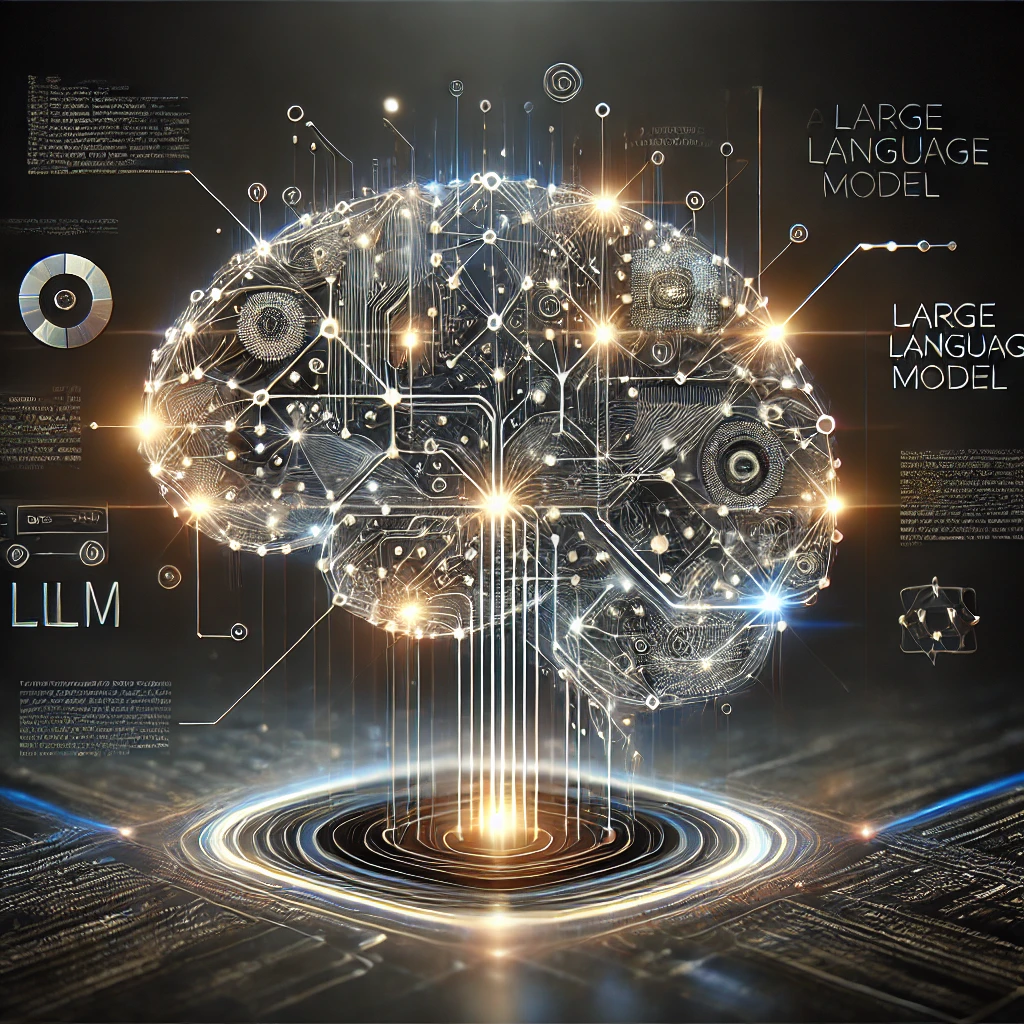

# 🔥🔥🔥Project Objective🔥🔥🔥

In this project, highlight several dynamic and powerful business use cases that can be automated using Large Language Models (LLMs), thereby helping businesses save time and money.

## 🎯 2. Inferring

- **Sentiment Analysis:** Perform sentiment analysis on customer reviews to gauge overall customer sentiment.
- **Emotion Identification:** Identify types of emotions associated with reviews (e.g., satisfaction, frustration).
- **Entity Extraction:** Extract names, labels, products, and other important information valuable for business insights.

## 🎯 3. Transformation

- **Text Translation:** Translate text into any language, facilitating global business operations with diverse employees and customers.
- **Universal Translation Tools:** Implement tools capable of handling multiple languages for seamless communication.
- **Tone Adjustment:** Adjust writing tone to suit the intended audience, enhancing communication effectiveness.
- **Custom Formatting:** Create custom formats for documents and communications to meet specific business requirements.
- **Spell Check and Grammar Tools:** Utilize spell check and grammar correction tools to maintain professionalism.

## 🎯 4. Expanding

- **Automated Response Generation:** Customize automated replies to customer emails by extracting specific details from their reviews, improving customer engagement and satisfaction.

# 🔥🔥🔥 Setup Environment 🔥🔥🔥

```python
from IPython.display import display, Markdown
```

```python
import openai
import os

from dotenv import load_dotenv, find_dotenv
_ = load_dotenv(find_dotenv()) # read local .env file

openai.api_key  = os.getenv('OPENAI_API_KEY')
```

```python
openai.api_key = my_key
```

```python
import emoji
```

```python
from openai import OpenAI
client = OpenAI(api_key=my_key)
```

```python
client = OpenAI(api_key=my_key)

def get_completion(prompt, model="gpt-4o"):
    messages = [{"role": "user", "content": prompt}]
    response = client.chat.completions.create(
        model=model,
        messages=messages,
        temperature=0
    )
    return response.choices[0].message.content
```

# ✅ Customer Review Summarization

**Efficiently condense customer feedback to capture key insights.**

```python
cus_review = """I had the pleasure of working with Kevin during the recent purchase of my home in West Harrison,/
New York, and I couldn't be more impressed with his service. From the very beginning,/
Kevin demonstrated a deep understanding of the mortgage process and tailored his approach to fit my unique needs./
His attention to detail and client-focused attitude made the entire experience seamless and stress-free./

Kevin was always available to answer any questions, providing clear explanations and prompt responses,/
which gave me a lot of confidence throughout the process. He and his team worked diligently to ensure everything stayed on track,/
and I was always kept in the loop. Thanks to his expertise, I was able to close smoothly and on time.

If you're looking for a mortgage professional who is knowledgeable, reliable, and truly cares about his clients,/
I highly recommend Kevin. He made the home buying process much easier and exceeded all my expectations."""
```

````python
prompt = f"""
Generate a short summary of a customer \
review from an Citimortgage site.

Summarize the review below, delimited by triple
backticks, in at most 30 words.

Review: ```{cus_review}```
"""

response = get_completion(prompt)
print(response)
````

```
The reviewer praises Kevin for his exceptional service, deep mortgage knowledge, attention to detail, and client-focused approach, making the home buying process seamless and stress-free. Highly recommended.
```

## ✅ Extract Valuable Insights

````python
prompt = f"""
Extract relevant information from \
a customer review from citimortgage site to give \
feedback to processing team.

From the review below, delimited by triple quotes \
extract the information relevant. Limit to 30 words.

Review: ```{cus_review}```
"""

response = get_completion(prompt)
print(response)
````

```
Kevin demonstrated a deep understanding of the mortgage process, provided clear explanations, prompt responses, and ensured a seamless, stress-free experience, leading to a smooth and timely closing.
```

# ✅ Department-Specific Details

**Identify and extract details relevant to specific departments (e.g., pricing, value, delivery, product quality).**

```python
product_review = """Okay, so I've been eyeing these Sony WH-1000XM4 headphones for months,/
and I finally bit the bullet during Prime Day. Best Decision!!!Ever.First off, the price I snagged these/
bad boys for $248, which is a steal considering they usually go for $349./
I was worried they wouldn't arrive in time for my trip, but Amazon Prime came through./
Ordered Wednesday night, and bam! They were on my doorstep Friday afternoon. Talk about fast shipping!
Now, about the headphones themselves holy cow. The noise cancellation is out of this world./
I wore them on a 6hour flight, and it was like I was in my own little bubble./
No crying babies, no engine noise, just me and my music. The sound quality? Crisp, clear, and the bass is chef's kiss.
Battery life is insane too./
I've been using them for a week now, about 3 to 4 hours a day, and I've only had to charge them once.
Oh, and the touch controls are so intuitive took me like 5 minutes to figure everything out./
Only tiny gripe is that they're a bit bulky for my small head, but honestly, the comfort makes up for it./
I can wear these for hours without any discomfort."""
```

````python
prompt = f"""
Generate a short summary of a product \
review from Amazon site to give feedback to the \
Shipping deparmtment.

Summarize the review below, delimited by triple
backticks, in at most 30 words, and focusing on any aspects \
that mention shipping, delivery and price of the product.

Review: ```{product_review}```
"""

response = get_completion(prompt)
print(response)
````

```
The reviewer praised the fast shipping, noting the headphones arrived in two days, and highlighted the excellent Prime Day price of $248, significantly lower than the usual $349.
```

# ✅ Inferring

## ✅ Sentiment Analysis

**Perform sentiment analysis on customer reviews to gauge overall customer sentiment**

```python
prompt = f"""
What is the sentiment of the customer review,
which is delimited with triple backticks?

Review text: '''{cus_review}'''
"""
response = get_completion(prompt)
print(response)
```

[output not shown]

```python
prompt = f"""
What is the sentiment of the product review,
which is delimited with triple backticks?

Give your answer as a single word, either "positive" \
or "negative".

Review text: '''{cus_review}'''
"""
response = get_completion(prompt)
print(response)
```

```
Positive
```

## ✅ Emotion Identification

**Identify types of emotions associated with reviews (e.g., satisfaction, frustration)**

```python
prompt = f"""
Identify a list of emotions that the writer of the \
following review is expressing. Include no more than \
five items in the list. Format your answer as a list of \
lower-case words separated by commas.

Review text: '''{cus_review}'''
"""
response = get_completion(prompt)
print(response)
```

```
gratitude, admiration, confidence, satisfaction, relief
```

## ✅ Is the Customer angry?

```python
prompt = f"""
Is the writer of the following review expressing anger?\
The review is delimited with triple backticks. \
Give your answer as either yes or no.

Review text: '''{cus_review}'''
"""
response = get_completion(prompt)
print(response)
```

```
No
```

```python
prod_review = """"The heat is instant and really well made in the US, not a Chinese imitation./
I actually think it is the same company as Dewalt./The site offered me a hose connection kit 'as/
if they are bought together' that was supposed to be made by Mr Heater (which I don't know if that is true)/
and was about 1m long and looked like a silver shower hose and had various different connectors so that you can connect it to virtually anything,/
but it didn't have the connector in the kit to connect it to the heater itself and I thought,/
I'll just order an adapter but no such thing existed. /
I had to return that and bought another hose by Mr Heater which is about 5m long for around the same price./
Be careful with the hoses as the cheap ones get destroyed by the oil and the corrosion/breakdown of the rubber/
goes into the heater and damages the heater and remember you are inhaling the toxins./
I also bought the oil filter from another site and got them imported from the US, /
it fits perfectly on the heater end of the attachment chain of things./
Still means the oil went down the pipe if it is a cheap nasty pipe or the mr heater pipe /
(which is graded and promise not to break down the rubber)/
and gets to the oil filter which prevents oil getting into the heater./
I say all this because propane is oil based gas... /
The little 1lb cannisters do not need the oil filter as they don't have the oil problem in the cannisters/
but the big red propane bottles do have the oil./I got a bag for it which is actually a cooler/
thermal rucksack and it fit the heater inside with the 1lb cannister laid on top and the front/
pocket with the hose etc. Half the price of the real branded Mr Heater bag"""
```

````python
prompt = f"""
Generate a short summary of a customer \
review from an Amazon site.

Summarize the review below, delimited by triple
backticks, in at most 30 words.

Review: ```{prod_review}```
"""

response = get_completion(prompt)
print(response)
````

```
Instant heat, well-made in the US. Issues with hose kit compatibility; recommend using Mr Heater hoses and oil filter. Propane bottles need careful handling to avoid oil damage.
```

```python
prompt = f"""
What is the sentiment of the product review,
which is delimited with triple backticks?

Give your answer as a single word, either "positive" \
or "negative".

Review text: '''{prod_review}'''
"""
response = get_completion(prompt)
print(response)
```

```
Negative
```

````python
prompt = f"""
Generate a short summary of a product \
review from Amazon site to give feedback to the \
Shipping deparmtment.

Summarize the review below, delimited by triple
backticks, in at most 30 words, and focusing on any aspects \
that mention shipping, delivery and price of the product.

Review: ```{product_review}```
"""

response = get_completion(prompt)
print(response)
````

```
Customer praised the fast shipping, receiving the Sony WH-1000XM4 headphones within two days. They also highlighted the excellent Prime Day price of $248, significantly lower than the usual $349.
```

```python
prompt = f"""
What is the sentiment of the product review,
which is delimited with triple backticks?

Give your answer as a single word, either "positive" \
or "negative".

Review text: '''{product_review}'''
"""
response = get_completion(prompt)
print(response)
```

```
Positive
```

## ✅ Entity Extraction

```python
story ="""The average American has racked up $6,500 in credit card debt,/
according to Experian data from the third quarter of last year./
This means they’re paying $116 a month in interest rate payments at May’s average rate of 21.5%./
But if interest rates were capped at 10%, they’d pay $54 a month in interest rate payments./
In addition to the money saved, this would “dramatically” shorten the length of/
time it takes people to pay off their credit card debt, Matt Schulz, chief credit analyst at LendingTree, told CNN./
But your ability to access credit in the future could suffer as a result./
“There’s no question that with a 10% rate cap, card issuers would put the/
clamps down on credit while they figure out how to continue making money in this new normal,” he said./
The reason: Interest rates are how credit card companies manage the risk that a
customer won’t pay their credit card bill on time./
Generally, customers with lower credit scores are deemed riskier to lend to./
To compensate, lenders tend to charge higher rates compared to borrowers
who have a score in the upper range. But if card issuers, namely banks,/
can’t charge the rates they otherwise would because of a cap, /
they’d have no choice but to stop lending to certain customers, said Schulz,/
the author of the book “Ask Questions, Save Money, Make More: How To Take Control Of Your Financial Life."""
```

```python
prompt = f"""
Determine five topics that are being discussed in the \
following text, which is delimited by triple backticks.

Make each item one or two words long.

Format your response as a list of items separated by commas.

Text sample: '''{story}'''
"""
response = get_completion(prompt)
print(response)
```

```
- Credit card debt
- Interest rates
- Rate cap
- Credit access
- Lending risk
```

````python
prompt = f"""
Generate a short summary of the story\
from today's new headline.

Summarize the review below, delimited by triple
backticks, in at most 30 words.

Review: ```{story}```
"""

response = get_completion(prompt)
print(response)
````

```
The average American's credit card debt is $6,500, costing $116 monthly in interest. A 10% interest rate cap would reduce this to $54 but limit future credit access.
```

# Text Translation

**Translate text into any language, facilitating global business operations with diverse employees and customers.**

````python
prompt = f"""
Translate the following English text to Spanish: \
```I am gratful```
"""
response = get_completion(prompt)
print(response)
````

````
```Estoy agradecido```
````

````python
prompt = f"""
Tell me which language this is:
```Huṁ ābhārī chuṁ```
"""
response = get_completion(prompt)
print(response)
````

```
The phrase "Huṁ ābhārī chuṁ" is in Gujarati, an Indo-Aryan language spoken predominantly in the Indian state of Gujarat. The phrase translates to "I am grateful" in English.
```

````python
prompt = f"""
Translate the following  text to French and Spanish
and English pirate: \
```I want to go on a vacation```
"""
response = get_completion(prompt)
print(response)
````

````
Sure! Here are the translations:

**French:**
```Je veux partir en vacances```

**Spanish:**
```Quiero irme de vacaciones```

**English Pirate:**
```I be wantin' t' go on a holiday```
````

```python
prompt = f"""
Translate the following text to Spanish in both the \
formal and informal forms:
'Would you like to go dancing?'
"""
response = get_completion(prompt)
print(response)
```

```
Sure! Here are the translations:

**Formal:**
¿Le gustaría ir a bailar?

**Informal:**
¿Te gustaría ir a bailar?
```

# ✅ Universal Translation Tools

**Implement tools capable of handling multiple languages for seamless communication.**

```python
user_messages =["Ne mogu voyti. Pis'mo dlya sbrosa parolya ne prikhodit.", # Can't log in. Password reset email not coming through
              "keompyuteoga maeu neulibnida. peulogeulaem-i jeongjidoebnida. dobda!", # Computer extremely slow. Programs freezing. Help
              "Se eliminaron archivos importantes por error. como recuperarse?",# Deleted important files by mistake. How to recover?
              "Daphatara dā priṭara kama nahīṁ kara rihā. Kanaikaṭa kītē śō para priṭa nahīṁ hōṇagē.",# Office printer not working. Shows connected but won't print
              "bloo skreen trutiyaan milatee rahatee hain. laipatop betarateeb dhang se punaraarambh hota hai."] # Keep getting Blue Screen errors. Laptop restarts randomly
```

````python
for issue in user_messages:
    prompt = f"Tell me what language this is: ```{issue}```"
    lang = get_completion(prompt)
    print(f"Original message ({lang}): {issue}")

    prompt = f"""
    Translate the following  text to English: ```{issue}```
    """
    response = get_completion(prompt)
    print(response, "\n")
````

````
Original message (The text you provided is in Russian. It translates to: "I can't log in. The password reset email is not coming."): Ne mogu voyti. Pis'mo dlya sbrosa parolya ne prikhodit.
"I can't log in. The password reset email isn't coming."

Original message (The text you provided appears to be a transliteration of Korean into the Latin alphabet (romanization). Here is a breakdown of the text:

- "keompyuteoga maeu neulibnida." translates to "The computer is very slow."
- "peulogeulaem-i jeongjidoebnida." translates to "The program is frozen."
- "dobda!" translates to "Help!"

So, the language is Korean, but written using the Latin alphabet instead of Hangul, the Korean script.): keompyuteoga maeu neulibnida. peulogeulaem-i jeongjidoebnida. dobda!
The translation of the text from Korean to English is: "The computer is very slow. The program is frozen. Help!"

Original message (The language of the text ```Se eliminaron archivos importantes por error. como recuperarse?``` is Spanish. In English, it translates to "Important files were deleted by mistake. How to recover?"): Se eliminaron archivos importantes por error. como recuperarse?
The text translates to English as: "Important files were deleted by mistake. How to recover?"

Original message (The text you provided appears to be in Punjabi, written in the Latin script (also known as Romanized Punjabi). Here is a rough translation of the text to English:

```Daphatara dā priṭara kama nahīṁ kara rihā. Kanaikaṭa kītē śō para priṭa nahīṁ hōṇagē.```

Translation:
```The office printer is not working. Even after trying, the print is not happening.```

Punjabi is an Indo-Aryan language spoken by the Punjabi people in the Punjab region of Pakistan and India. It is written in different scripts, including Gurmukhi in India and Shahmukhi in Pakistan, but it can also be transliterated into the Latin alphabet for ease of use in digital communication.): …
The printer is not working. Even after connecting it, the print is not happening.

Original message (The text you provided is written in Hindi, but it is transliterated using the Latin alphabet (Roman script). Here is the transliteration in Devanagari script, which is the standard script for writing Hindi:

```हिंदी: ब्लू स्क्रीन त्रुटियाँ मिलती रहती हैं। लैपटॉप बेतरतीब ढंग से पुनःआरंभ होता है।```

In English, this translates to:

```English: Blue screen errors keep occurring. The laptop restarts randomly.```): bloo skreen trutiyaan milatee rahatee hain. laipatop betarateeb dhang se punaraarambh hota hai.
The translation of the text to English is: "Blue screen errors keep occurring. The laptop restarts randomly."
````

# ✅ Tone Adjustment

**Adjust writing tone to suit the intended audience, enhancing communication effectiveness.**

```python
prompt = f"""
Translate the following from slang to a business letter:
'Dude, This is Sam, check out this spec on BMW X4 2024.'
"""
response = get_completion(prompt)
print(response)
```

```
Subject: Review of BMW X4 2024 Specifications

Dear [Recipient's Name],

I hope this message finds you well.

I am writing to bring to your attention the specifications of the BMW X4 2024 model. I believe you will find the details quite impressive and relevant to our current interests.

Please take a moment to review the attached specifications document.

Best regards,

Sam
```

```python
sentiment = "negative"


review = f"""
So, they still had the 17 piece system on seasonal \
sale for around $49 in the month of November, about \
half off, but for some reason (call it price gouging) \
around the second week of December the prices all went \
up to about anywhere from between $70-$89 for the same \
system. And the 11 piece system went up around $10 or \
so in price also from the earlier sale price of $29. \
So it looks okay, but if you look at the base, the part \
where the blade locks into place doesn’t look as good \
as in previous editions from a few years ago, but I \
plan to be very gentle with it (example, I crush \
very hard items like beans, ice, rice, etc. in the \
blender first then pulverize them in the serving size \
I want in the blender then switch to the whipping \
blade for a finer flour, and use the cross cutting blade \
first when making smoothies, then use the flat blade \
if I need them finer/less pulpy). Special tip when making \
smoothies, finely cut and freeze the fruits and \
vegetables (if using spinach-lightly stew soften the \
spinach then freeze until ready for use-and if making \
sorbet, use a small to medium sized food processor) \
that you plan to use that way you can avoid adding so \
much ice if at all-when making your smoothie. \
After about a year, the motor was making a funny noise. \
I called customer service but the warranty expired \
already, so I had to buy another one. FYI: The overall \
quality has gone done in these types of products, so \
they are kind of counting on brand recognition and \
consumer loyalty to maintain sales. Got it in about \
two days.
"""
```

````python
prompt = f"""
You are a customer service AI assistant.
Your task is to send an email reply to a valued customer.
Given the customer email delimited by ```, \
Generate a reply to thank the customer for their review.
If the sentiment is positive or neutral, thank them for \
their review.
If the sentiment is negative, apologize and suggest that \
they can reach out to customer service.
Make sure to use specific details from the review.
Write in a concise and professional tone.
Sign the email as `AI customer agent`.
Customer review: ```{review}```
Review sentiment: {sentiment}
"""
response = get_completion(prompt)
print(response)
````

```
Subject: Thank You for Your Feedback

Dear Valued Customer,

Thank you for taking the time to share your detailed review of our 17-piece and 11-piece systems. We sincerely apologize for the inconvenience you experienced with the price changes and the quality of the product.

We understand your frustration regarding the price increase during the holiday season and the issues you encountered with the blade locking mechanism and motor performance. Your feedback is invaluable to us, and we will certainly take it into consideration for future improvements.

If you have any further concerns or need assistance, please do not hesitate to reach out to our customer service team. We are here to help and ensure you have a satisfactory experience with our products.

Thank you once again for your feedback.

Best regards,

AI Customer Agent
```

## ✅ Custom Formatting

```python
data_json = { "Bank employees" :[
    {"name":"Sam", "email":"sampaul@gmail.com"},
    {"name":"Peter", "email":"peter28@gmail.com"},
    {"name":"Jose", "email":"jose7@gmail.com"}
]}

prompt = f"""
Translate the following python dictionary from JSON to an HTML \
table with column headers and title: {data_json}
"""
response = get_completion(prompt)
print(response)
```

````
To convert the given Python dictionary to an HTML table with column headers and a title, you can follow these steps:

1. Extract the data from the dictionary.
2. Create the HTML structure with a title and table headers.
3. Populate the table rows with the data.

Here's the HTML code for the given dictionary:

```html
<!DOCTYPE html>
<html lang="en">
<head>
    <meta charset="UTF-8">
    <meta name="viewport" content="width=device-width, initial-scale=1.0">
    <title>Bank Employees</title>
    <style>
        table {
            width: 50%;
            border-collapse: collapse;
            margin: 25px 0;
            font-size: 18px;
            text-align: left;
        }
        th, td {
            padding: 12px;
            border-bottom: 1px solid #ddd;
        }
        th {
            background-color: #f2f2f2;
        }
    </style>
</head>
<body>
    <h1>Bank Employees</h1>
    <table>
        <thead>
            <tr>
                <th>Name</th>
                <th>Email</th>
            </tr>
        </thead>
        <tbody>
            <tr>
                <td>Sam</td>
                <td>sampaul@gmail.com</td>
            </tr>
            <tr>
                <td>Peter</td>
                <td>peter28@gmail.com</td>
            </tr>
            <tr>
                <td>Jose</td>
                <td>jose7@gmail.com</td>
            </tr>
        </tbody>
    </table>
</body>
</html>
```

This HTML code will create a table with the title "Bank Employees" and two columns: "Name" and "Email". Each row in the table corresponds to an employee from the dictionary. The table is styled with some basic CSS for better readability.
````

```python
from IPython.display import display, Markdown, Latex, HTML, JSON
display(HTML(response))
```

To convert the given Python dictionary to an HTML table with column headers and a title, you can follow these steps: 1. Extract the data from the dictionary. 2. Create the HTML structure with a title and table headers. 3. Populate the table rows with the data. Here's the HTML code for the given dictionary: ```html

Bank Employees

| Name | Email |
| --- | --- |
| Sam | sampaul@gmail.com |
| Peter | peter28@gmail.com |
| Jose | jose7@gmail.com |

``` This HTML code will create a table with the title "Bank Employees" and two columns: "Name" and "Email". Each row in the table corresponds to an employee from the dictionary. The table is styled with some basic CSS for better readability.

# ✅ Spell Check and Grammar Tools

**Utilize spell check and grammar correction tools to maintain professionalism.**

````python
text = [ "The cat with the orange and white stripes has caught it's prey.",  # Possessive error
    "Marcus has his backpack.",  # Correct sentence
    "Its going to rain today. Is the umbrella in it's place?",  # Homonyms
    "They're car broke down. Their going to need a ride over there.",  # Homonyms
    "You're jacket is on you're chair.",  # Homonyms
    "The loud noise affects my concentration. Did you know about the domino affect?",  # Homonyms
    "This sentense is two test thee spell checking capabilitie"  # Spelling and grammar
]
for t in text:
    prompt = f"""Proofread and correct the following text
    and rewrite the corrected version. If you don't find
    and errors, just say "No errors found". Don't use
    any punctuation around the text:
    ```{t}```"""
    response = get_completion(prompt)
    print(response)
````

```
The cat with the orange and white stripes has caught its prey.
No errors found
Its going to rain today. Is the umbrella in its place?
Their car broke down. They're going to need a ride over there.
Your jacket is on your chair.
The loud noise affects my concentration. Did you know about the domino effect?
This sentence is to test the spell checking capability
```

````python
text = f"""
Bought this coffee maker for my office becuz everyone was \
tired of the old one. Its amazing how much better the coffee \
tastes now! The machine is realy easy to use, just pop in a \
pod and press the button. It heats up quick to, which is great \
for those busy mornings. The only downside is that it's a bit \
louder than are old machine. But the speed make's up for it. \
The water tank could of been bigger, we have to refill it often. \
It arrived quicker than expected which was a nice surprise, we \
got to use it for our Monday morning meeting.
"""


prompt = f"proofread and correct this review: ```{text}```"
response = get_completion(prompt)
print(response)
````

[output not shown]

```python
from redlines import Redlines

diff = Redlines(text,response)
display(Markdown(diff.output_markdown))
```

Bought this coffee maker for my office becuz because everyone was tired of the old one. Its It's amazing how much better the coffee tastes now! The machine is realy really easy to use, use; just pop in a pod and press the button. It heats up quick to, quickly too, which is great for those busy mornings. The only downside is that it's a bit louder than are our old machine. But machine, but the speed make's makes up for it. The water tank could of have been bigger, bigger; we have to refill it often. It arrived quicker than expected expected, which was a nice surprise, we surprise. We got to use it for our Monday morning meeting.

# ✅ Expanding

## Automated Response Generation

**Customize automated replies to customer emails by extracting specific details from their reviews, improving customer engagement and satisfaction.**

```python
sentiment = "negative"

phone_review = f"""I deeply regret purchasing the TechGlide X20 smartphone. /
Where do I even begin? The battery life is abysmal. I'm lucky if it lasts half a day with minimal use./
The camera, which was heavily advertised as 'revolutionary,' produces grainy, washed-out photos that look like they/
were taken with a flip phone from 2005./The user interface is clunky and unintuitive,/
with frequent freezes and app crashes./
I've had to restart the phone multiple times a day just to keep it functioning./
The much-touted 5G capability? A joke. I get better speeds on my old 4G device.
To add insult to injury, customer support has been utterly unhelpful./
I've spent hours on hold, only to be told that these issues are 'within normal parameters.'/
Normal? For a $1000 phone?Save yourself the headache and money./
This phone is a prime example of style over substance, /
and I'm counting down the days until I can replace it./
Definitely not worth the hype or the price tag. One star, and that's being generous."""
```

````python
prompt = f"""
You are a customer service AI assistant.
Your task is to send an email reply to a valued customer.
Given the customer email delimited by ```, \
Generate a reply to thank the customer for their review.
If the sentiment is positive or neutral, thank them for \
their review.
If the sentiment is negative, apologize and suggest that \
they can reach out to customer service.
Make sure to use specific details from the review.
Write in a concise and professional tone.
Sign the email as `AI customer agent`.
Customer review: ```{phone_review}```
Review sentiment: {sentiment}
"""
response = get_completion(prompt)
print(response)
````

[output not shown]

## 📌 Conclusion:

**This project demonstrated how the implementation of Large Language Models (LLMs) enables businesses to automate tasks efficiently, requiring minimal resources and time. These are just a few examples; however, there are many more ways in which LLMs can help businesses streamline operations. Stay tuned for more**